# 03 - Hypothesis Tests and Regression

Caylee Collins and Kate Miller

# 1 Setup

```r
# Load packages required for statistical comparisons.
required_packages <- c("dplyr", "tidyr", "ggplot2", "knitr")
missing_packages <- required_packages[
  !vapply(required_packages, requireNamespace, logical(1), quietly = TRUE)
]

if (length(missing_packages) > 0) {
  stop("Install these packages first: ", paste(missing_packages, collapse = ", "))
}

library(dplyr)
library(tidyr)
library(ggplot2)
library(knitr)
```

# 2 Load Data

```r
# Find the project root whether knitting from code/ or the project root.
project_root <- if (file.exists("data/processed/pre_covid_clean.csv")) {
  "."
} else if (file.exists("../data/processed/pre_covid_clean.csv")) {
  ".."
} else {
  stop("Cannot locate data/processed/pre_covid_clean.csv. Open the project .Rproj first.")
}

# Read the two processed datasets without modifying the originals.
pre_path <- file.path(project_root, "data", "processed", "pre_covid_clean.csv")
post_path <- file.path(project_root, "data", "processed", "post_covid_clean.csv")

if (!file.exists(post_path)) {
  stop("Missing processed post-COVID dataset: ", post_path)
}

pre_covid <- read.csv(pre_path, check.names = FALSE)
post_covid <- read.csv(post_path, check.names = FALSE)

# Check the shared variables needed for comparisons.
required_columns <- c("PHQ", "GAD", "gender", "field", "race.2",
                      "yr_sch.2", "fincur.2", "age")

for (dataset_name in c("pre_covid", "post_covid")) {
  missing_columns <- setdiff(required_columns, names(get(dataset_name)))
  if (length(missing_columns) > 0) {
    stop(dataset_name, " is missing: ", paste(missing_columns, collapse = ", "))
  }
}

# Confirm sample sizes.
data.frame(
  Dataset = c("Pre-COVID (2017–2018)", "Post-COVID (2022–2023)"),
  N = c(nrow(pre_covid), nrow(post_covid))
) |> knitr::kable()
```

| Dataset | N |
| --- | --- |
| Pre-COVID (2017–2018) | 68427 |
| Post-COVID (2022–2023) | 43910 |

# 3 Clean Pre-COVID and Post-COVID Data

```r
# Standardize survey periods and demographic categories across datasets.
# Convert outcomes and numeric predictors to numeric values, then combine the samples.
pre_covid$Period <- "2017-2018 Pre-COVID"
post_covid$Period <- "2022-2023 Post-COVID"

post_covid$field <- as.character(post_covid$field)
pre_covid$field <- as.character(pre_covid$field)

post_covid$field[post_covid$field == "NotSTEM"] <- "Non-STEM"
pre_covid$field[pre_covid$field == "NotSTEM"] <- "Non-STEM"

pre_covid$gender <- factor(
  pre_covid$gender,
  levels = c("Men", "Women")
)

post_covid$gender <- factor(
  post_covid$gender,
  levels = c("Men", "Women")
)

pre_covid$field <- factor(
  pre_covid$field,
  levels = c("Non-STEM", "STEM")
)

post_covid$field <- factor(
  post_covid$field,
  levels = c("Non-STEM", "STEM")
)

race_levels <- c(
  "White",
  "Asian",
  "Black",
  "Hispanic",
  "Middle Eastern"
)

pre_covid$race.2 <- factor(
  pre_covid$race.2,
  levels = race_levels
)

post_covid$race.2 <- factor(
  post_covid$race.2,
  levels = race_levels
)

year_levels <- c(
  "firstyear",
  "secondyear",
  "thirdyear",
  "fourthyear+"
)

pre_covid$yr_sch.2 <- factor(
  pre_covid$yr_sch.2,
  levels = year_levels
)

post_covid$yr_sch.2 <- factor(
  post_covid$yr_sch.2,
  levels = year_levels
)

pre_covid$PHQ <- as.numeric(pre_covid$PHQ)
pre_covid$GAD <- as.numeric(pre_covid$GAD)
pre_covid$fincur.2 <- as.numeric(pre_covid$fincur.2)
pre_covid$age <- as.numeric(pre_covid$age)

post_covid$PHQ <- as.numeric(post_covid$PHQ)
post_covid$GAD <- as.numeric(post_covid$GAD)
post_covid$fincur.2 <- as.numeric(post_covid$fincur.2)
post_covid$age <- as.numeric(post_covid$age)

combined <- bind_rows(
  pre_covid,
  post_covid
)

combined$Period <- factor(
  combined$Period,
  levels = c(
    "2017-2018 Pre-COVID",
    "2022-2023 Post-COVID"
  )
)
```

# 4 Pre-COVID vs Post-COVID Hypothesis Tests

## 4.1 Depression

```r
# Use a two-sample t-test to compare average depression (PHQ) scores
# between the pre-COVID and post-COVID survey periods.
phq_test <- t.test(
  PHQ ~ Period,
  data = combined
)

phq_test
```

```
##
##  Welch Two Sample t-test
##
## data:  PHQ by Period
## t = -21.629, df = 86849, p-value < 2.2e-16
## alternative hypothesis: true difference in means between group 2017-2018 Pre-COVID and group 2022-2023 Post-COVID is not equal to 0
## 95 percent confidence interval:
##  -0.10710390 -0.08930565
## sample estimates:
##  mean in group 2017-2018 Pre-COVID mean in group 2022-2023 Post-COVID
##                           1.892220                           1.990424
```

*Interpretation note:* Use the numerical output above when reporting the direction, magnitude, and significance of this comparison.

## 4.2 Anxiety

```r
# Use a two-sample t-test to compare average anxiety (GAD) scores
# between the pre-COVID and post-COVID survey periods.
gad_test <- t.test(
  GAD ~ Period,
  data = combined
)

gad_test
```

```
##
##  Welch Two Sample t-test
##
## data:  GAD by Period
## t = -31.798, df = 85819, p-value < 2.2e-16
## alternative hypothesis: true difference in means between group 2017-2018 Pre-COVID and group 2022-2023 Post-COVID is not equal to 0
## 95 percent confidence interval:
##  -0.1817939 -0.1606839
## sample estimates:
##  mean in group 2017-2018 Pre-COVID mean in group 2022-2023 Post-COVID
##                           1.983590                           2.154828
```

*Interpretation note:* Use the numerical output above when reporting the direction, magnitude, and significance of this comparison.

# 5 Student Characteristic Differences

## 5.1 Age

```r
# Test whether the average student age differs between survey periods.
age_test <- t.test(
  age ~ Period,
  data = combined
)

age_test
```

```
##
##  Welch Two Sample t-test
##
## data:  age by Period
## t = 61.229, df = 109641, p-value < 2.2e-16
## alternative hypothesis: true difference in means between group 2017-2018 Pre-COVID and group 2022-2023 Post-COVID is not equal to 0
## 95 percent confidence interval:
##  1.920245 2.047248
## sample estimates:
##  mean in group 2017-2018 Pre-COVID mean in group 2022-2023 Post-COVID
##                           22.95718                           20.97343
```

*Interpretation note:* Use the numerical output above when reporting the direction, magnitude, and significance of this comparison.

## 5.2 Financial Stress

```r
# Compare average current financial stress scores across survey periods.
financial_test <- t.test(
  fincur.2 ~ Period,
  data = combined
)

financial_test
```

```
##
##  Welch Two Sample t-test
##
## data:  fincur.2 by Period
## t = -36.117, df = 91040, p-value < 2.2e-16
## alternative hypothesis: true difference in means between group 2017-2018 Pre-COVID and group 2022-2023 Post-COVID is not equal to 0
## 95 percent confidence interval:
##  -0.2626337 -0.2355957
## sample estimates:
##  mean in group 2017-2018 Pre-COVID mean in group 2022-2023 Post-COVID
##                           2.882012                           3.131127
```

*Interpretation note:* Use the numerical output above when reporting the direction, magnitude, and significance of this comparison.

## 5.3 Gender

```r
# Create a period-by-gender frequency table and use a chi-square test
# to examine whether the gender distribution differs across periods.
gender_table <- table(
  combined$Period,
  combined$gender
)

gender_table
```

```
##
##                          Men Women
##   2017-2018 Pre-COVID  21541 45010
##   2022-2023 Post-COVID 12271 31639
```

```r
gender_test <- chisq.test(
  gender_table
)

gender_test
```

```
##
##  Pearson's Chi-squared test with Yates' continuity correction
##
## data:  gender_table
## X-squared = 243.33, df = 1, p-value < 2.2e-16
```

*Interpretation note:* Use the numerical output above when reporting the direction, magnitude, and significance of this comparison.

## 5.4 STEM Status

```r
# Compare the proportion of STEM and non-STEM students across periods
# using a contingency table and chi-square test.
stem_table <- table(
  combined$Period,
  combined$field
)

stem_table
```

```
##
##                        Non-STEM  STEM
##   2017-2018 Pre-COVID     32173 25099
##   2022-2023 Post-COVID    18957 22065
```

```r
stem_test <- chisq.test(
  stem_table
)

stem_test
```

```
##
##  Pearson's Chi-squared test with Yates' continuity correction
##
## data:  stem_table
## X-squared = 950.35, df = 1, p-value < 2.2e-16
```

*Interpretation note:* Use the numerical output above when reporting the direction, magnitude, and significance of this comparison.

## 5.5 Race

```r
# Test whether the distribution of reported race categories
# differs between the pre-COVID and post-COVID samples.
race_table <- table(
  combined$Period,
  combined$race.2
)

race_table
```

```
##
##                        White Asian Black Hispanic Middle Eastern
##   2017-2018 Pre-COVID  40349 10167  3406     4940           1112
##   2022-2023 Post-COVID 25215  5118  4446     3332            647
```

```r
race_test <- chisq.test(
  race_table
)

race_test
```

```
##
##  Pearson's Chi-squared test
##
## data:  race_table
## X-squared = 1232.3, df = 4, p-value < 2.2e-16
```

*Interpretation note:* Use the numerical output above when reporting the direction, magnitude, and significance of this comparison.

## 5.6 Year in School

```r
# Use a chi-square test to compare year-in-school distributions
# across the two survey periods.
year_table <- table(
  combined$Period,
  combined$yr_sch.2
)

year_table
```

```
##
##                        firstyear secondyear thirdyear fourthyear+
##   2017-2018 Pre-COVID      20665      17477     13481       10813
##   2022-2023 Post-COVID     11639      10498     10567       10789
```

```r
year_test <- chisq.test(
  year_table
)

year_test
```

```
##
##  Pearson's Chi-squared test
##
## data:  year_table
## X-squared = 1269.2, df = 3, p-value < 2.2e-16
```

*Interpretation note:* Use the numerical output above when reporting the direction, magnitude, and significance of this comparison.

# 6 Depression Changes by Gender

```r
# Compare pre- and post-COVID depression scores separately for men
# and women using two-sample t-tests within each gender group.
men_phq <- t.test(
  PHQ ~ Period,
  data = combined %>%
    filter(gender == "Men")
)

women_phq <- t.test(
  PHQ ~ Period,
  data = combined %>%
    filter(gender == "Women")
)

men_phq
```

```
##
##  Welch Two Sample t-test
##
## data:  PHQ by Period
## t = -10.406, df = 23800, p-value < 2.2e-16
## alternative hypothesis: true difference in means between group 2017-2018 Pre-COVID and group 2022-2023 Post-COVID is not equal to 0
## 95 percent confidence interval:
##  -0.10139741 -0.06925346
## sample estimates:
##  mean in group 2017-2018 Pre-COVID mean in group 2022-2023 Post-COVID
##                           1.777596                           1.862922
```

```r
women_phq
```

```
##
##  Welch Two Sample t-test
##
## data:  PHQ by Period
## t = -23.054, df = 61934, p-value < 2.2e-16
## alternative hypothesis: true difference in means between group 2017-2018 Pre-COVID and group 2022-2023 Post-COVID is not equal to 0
## 95 percent confidence interval:
##  -0.1351226 -0.1139469
## sample estimates:
##  mean in group 2017-2018 Pre-COVID mean in group 2022-2023 Post-COVID
##                           1.915265                           2.039800
```

*Interpretation note:* Use the numerical output above when reporting the direction, magnitude, and significance of this comparison.

# 7 Anxiety Changes by Gender

```r
# Compare pre- and post-COVID anxiety scores separately for men
# and women using two-sample t-tests within each gender group.
men_gad <- t.test(
  GAD ~ Period,
  data = combined %>%
    filter(gender == "Men")
)

women_gad <- t.test(
  GAD ~ Period,
  data = combined %>%
    filter(gender == "Women")
)

men_gad
```

```
##
##  Welch Two Sample t-test
##
## data:  GAD by Period
## t = -13.274, df = 23726, p-value < 2.2e-16
## alternative hypothesis: true difference in means between group 2017-2018 Pre-COVID and group 2022-2023 Post-COVID is not equal to 0
## 95 percent confidence interval:
##  -0.1428441 -0.1060874
## sample estimates:
##  mean in group 2017-2018 Pre-COVID mean in group 2022-2023 Post-COVID
##                           1.783758                           1.908224
```

```r
women_gad
```

```
##
##  Welch Two Sample t-test
##
## data:  GAD by Period
## t = -31.493, df = 61530, p-value < 2.2e-16
## alternative hypothesis: true difference in means between group 2017-2018 Pre-COVID and group 2022-2023 Post-COVID is not equal to 0
## 95 percent confidence interval:
##  -0.2156048 -0.1903401
## sample estimates:
##  mean in group 2017-2018 Pre-COVID mean in group 2022-2023 Post-COVID
##                           2.047305                           2.250277
```

*Interpretation note:* Use the numerical output above when reporting the direction, magnitude, and significance of this comparison.

# 8 Depression Changes by STEM Status

```r
# Test changes in depression scores across survey periods separately
# for STEM and non-STEM students.
nonstem_phq <- t.test(
  PHQ ~ Period,
  data = combined %>%
    filter(field == "Non-STEM")
)

stem_phq <- t.test(
  PHQ ~ Period,
  data = combined %>%
    filter(field == "STEM")
)

nonstem_phq
```

```
##
##  Welch Two Sample t-test
##
## data:  PHQ by Period
## t = -5.7139, df = 38337, p-value = 1.112e-08
## alternative hypothesis: true difference in means between group 2017-2018 Pre-COVID and group 2022-2023 Post-COVID is not equal to 0
## 95 percent confidence interval:
##  -0.05194366 -0.02540956
## sample estimates:
##  mean in group 2017-2018 Pre-COVID mean in group 2022-2023 Post-COVID
##                           1.941379                           1.980055
```

```r
stem_phq
```

```
##
##  Welch Two Sample t-test
##
## data:  PHQ by Period
## t = -23.563, df = 38552, p-value < 2.2e-16
## alternative hypothesis: true difference in means between group 2017-2018 Pre-COVID and group 2022-2023 Post-COVID is not equal to 0
## 95 percent confidence interval:
##  -0.1738548 -0.1471531
## sample estimates:
##  mean in group 2017-2018 Pre-COVID mean in group 2022-2023 Post-COVID
##                           1.840244                           2.000748
```

*Interpretation note:* Use the numerical output above when reporting the direction, magnitude, and significance of this comparison.

# 9 Anxiety Changes by STEM Status

```r
# Test changes in anxiety scores across survey periods separately
# for STEM and non-STEM students.
nonstem_gad <- t.test(
  GAD ~ Period,
  data = combined %>%
    filter(field == "Non-STEM")
)

stem_gad <- t.test(
  GAD ~ Period,
  data = combined %>%
    filter(field == "STEM")
)

nonstem_gad
```

```
##
##  Welch Two Sample t-test
##
## data:  GAD by Period
## t = -13.477, df = 37789, p-value < 2.2e-16
## alternative hypothesis: true difference in means between group 2017-2018 Pre-COVID and group 2022-2023 Post-COVID is not equal to 0
## 95 percent confidence interval:
##  -0.12367005 -0.09226496
## sample estimates:
##  mean in group 2017-2018 Pre-COVID mean in group 2022-2023 Post-COVID
##                           2.032844                           2.140811
```

```r
stem_gad
```

```
##
##  Welch Two Sample t-test
##
## data:  GAD by Period
## t = -29.431, df = 38038, p-value < 2.2e-16
## alternative hypothesis: true difference in means between group 2017-2018 Pre-COVID and group 2022-2023 Post-COVID is not equal to 0
## 95 percent confidence interval:
##  -0.2543802 -0.2226137
## sample estimates:
##  mean in group 2017-2018 Pre-COVID mean in group 2022-2023 Post-COVID
##                           1.924117                           2.162614
```

*Interpretation note:* Use the numerical output above when reporting the direction, magnitude, and significance of this comparison.

# 10 Did Relationships Change After COVID?

## 10.1 Depression and Gender

```r
# Fit a period-by-gender interaction model for depression to assess
# whether the gender difference in PHQ scores varies by survey period.
phq_gender_interaction <- lm(
  PHQ ~ Period * gender,
  data = combined
)

summary(phq_gender_interaction)
```

```
##
## Call:
## lm(formula = PHQ ~ Period * gender, data = combined)
##
## Residuals:
##     Min      1Q  Median      3Q     Max
## -1.0398 -0.5296 -0.1375  0.4046  2.2224
##
## Coefficients:
##                                        Estimate Std. Error t value Pr(>|t|)
## (Intercept)                            1.777596   0.005454 325.947  < 2e-16
## Period2022-2023 Post-COVID             0.085325   0.008312  10.265  < 2e-16
## genderWomen                            0.137668   0.006546  21.030  < 2e-16
## Period2022-2023 Post-COVID:genderWomen 0.039209   0.009871   3.972 7.13e-05
##
## (Intercept)                            ***
## Period2022-2023 Post-COVID             ***
## genderWomen                            ***
## Period2022-2023 Post-COVID:genderWomen ***
## ---
## Signif. codes:  0 '***' 0.001 '**' 0.01 '*' 0.05 '.' 0.1 ' ' 1
##
## Residual standard error: 0.6749 on 91518 degrees of freedom
##   (20815 observations deleted due to missingness)
## Multiple R-squared:  0.01824,    Adjusted R-squared:  0.01821
## F-statistic: 566.7 on 3 and 91518 DF,  p-value: < 2.2e-16
```

*Interpretation note:* Use the numerical output above when reporting the direction, magnitude, and significance of this comparison.

## 10.2 Depression and STEM Status

```r
# Fit a period-by-STEM interaction model for depression to assess
# whether the STEM/non-STEM difference varies by survey period.
phq_stem_interaction <- lm(
  PHQ ~ Period * field,
  data = combined
)

summary(phq_stem_interaction)
```

```
##
## Call:
## lm(formula = PHQ ~ Period * field, data = combined)
##
## Residuals:
##     Min      1Q  Median      3Q     Max
## -1.0008 -0.5356 -0.1636  0.3920  2.1598
##
## Coefficients:
##                                       Estimate Std. Error t value Pr(>|t|)
## (Intercept)                           1.941379   0.004258 455.990  < 2e-16
## Period2022-2023 Post-COVID            0.038677   0.006639   5.825 5.72e-09
## fieldSTEM                            -0.101135   0.006687 -15.123  < 2e-16
## Period2022-2023 Post-COVID:fieldSTEM  0.121827   0.009637  12.642  < 2e-16
##
## (Intercept)                          ***
## Period2022-2023 Post-COVID           ***
## fieldSTEM                            ***
## Period2022-2023 Post-COVID:fieldSTEM ***
## ---
## Signif. codes:  0 '***' 0.001 '**' 0.01 '*' 0.05 '.' 0.1 ' ' 1
##
## Residual standard error: 0.6858 on 82949 degrees of freedom
##   (29384 observations deleted due to missingness)
## Multiple R-squared:  0.007185,   Adjusted R-squared:  0.007149
## F-statistic: 200.1 on 3 and 82949 DF,  p-value: < 2.2e-16
```

*Interpretation note:* Use the numerical output above when reporting the direction, magnitude, and significance of this comparison.

## 10.3 Anxiety and Gender

```r
# Fit a period-by-gender interaction model for anxiety to assess
# whether the gender difference in GAD scores varies by survey period.
gad_gender_interaction <- lm(
  GAD ~ Period * gender,
  data = combined
)

summary(gad_gender_interaction)
```

```
##
## Call:
## lm(formula = GAD ~ Period * gender, data = combined)
##
## Residuals:
##     Min      1Q  Median      3Q     Max
## -1.2503 -0.6225 -0.1902  0.5241  2.2162
##
## Coefficients:
##                                        Estimate Std. Error t value Pr(>|t|)
## (Intercept)                            1.783758   0.006446 276.714  < 2e-16
## Period2022-2023 Post-COVID             0.124466   0.009818  12.677  < 2e-16
## genderWomen                            0.263546   0.007735  34.071  < 2e-16
## Period2022-2023 Post-COVID:genderWomen 0.078507   0.011658   6.734 1.66e-11
##
## (Intercept)                            ***
## Period2022-2023 Post-COVID             ***
## genderWomen                            ***
## Period2022-2023 Post-COVID:genderWomen ***
## ---
## Signif. codes:  0 '***' 0.001 '**' 0.01 '*' 0.05 '.' 0.1 ' ' 1
##
## Residual standard error: 0.7926 on 90528 degrees of freedom
##   (21805 observations deleted due to missingness)
## Multiple R-squared:  0.04193,    Adjusted R-squared:  0.04189
## F-statistic:  1321 on 3 and 90528 DF,  p-value: < 2.2e-16
```

*Interpretation note:* Use the numerical output above when reporting the direction, magnitude, and significance of this comparison.

## 10.4 Anxiety and STEM Status

```r
# Fit a period-by-STEM interaction model for anxiety to assess
# whether the STEM/non-STEM difference varies by survey period.
gad_stem_interaction <- lm(
  GAD ~ Period * field,
  data = combined
)

summary(gad_stem_interaction)
```

```
##
## Call:
## lm(formula = GAD ~ Period * field, data = combined)
##
## Residuals:
##     Min      1Q  Median      3Q     Max
## -1.1626 -0.6384 -0.1757  0.5517  2.0759
##
## Coefficients:
##                                       Estimate Std. Error t value Pr(>|t|)
## (Intercept)                           2.032844   0.005046  402.84   <2e-16
## Period2022-2023 Post-COVID            0.107968   0.007864   13.73   <2e-16
## fieldSTEM                            -0.108726   0.007932  -13.71   <2e-16
## Period2022-2023 Post-COVID:fieldSTEM  0.130529   0.011423   11.43   <2e-16
##
## (Intercept)                          ***
## Period2022-2023 Post-COVID           ***
## fieldSTEM                            ***
## Period2022-2023 Post-COVID:fieldSTEM ***
## ---
## Signif. codes:  0 '***' 0.001 '**' 0.01 '*' 0.05 '.' 0.1 ' ' 1
##
## Residual standard error: 0.8085 on 82038 degrees of freedom
##   (30295 observations deleted due to missingness)
## Multiple R-squared:  0.01244,    Adjusted R-squared:  0.01241
## F-statistic: 344.6 on 3 and 82038 DF,  p-value: < 2.2e-16
```

*Interpretation note:* Use the numerical output above when reporting the direction, magnitude, and significance of this comparison.

# 11 Adjusted Pre/Post Models

## 11.1 Adjusted Depression Model

```r
# Estimate the difference in depression scores between survey periods
# while adjusting for gender, STEM status, race, year, financial stress, and age.
adjusted_phq <- lm(
  PHQ ~ Period +
    gender +
    field +
    race.2 +
    yr_sch.2 +
    fincur.2 +
    age,
  data = combined
)

summary(adjusted_phq)
```

```
##
## Call:
## lm(formula = PHQ ~ Period + gender + field + race.2 + yr_sch.2 +
##     fincur.2 + age, data = combined)
##
## Residuals:
##     Min      1Q  Median      3Q     Max
## -1.1810 -0.5124 -0.1364  0.3933  2.3704
##
## Coefficients:
##                              Estimate Std. Error t value Pr(>|t|)
## (Intercept)                 1.9134761  0.0139819 136.854  < 2e-16 ***
## Period2022-2023 Post-COVID  0.0793011  0.0053205  14.905  < 2e-16 ***
## genderWomen                 0.1468018  0.0055820  26.299  < 2e-16 ***
## fieldSTEM                  -0.0381563  0.0051641  -7.389 1.50e-13 ***
## race.2Asian                 0.0191323  0.0072807   2.628   0.0086 **
## race.2Black                 0.0576078  0.0093277   6.176 6.61e-10 ***
## race.2Hispanic              0.0823411  0.0092388   8.913  < 2e-16 ***
## race.2Middle Eastern        0.1248897  0.0202479   6.168 6.95e-10 ***
## yr_sch.2secondyear          0.0624867  0.0068400   9.135  < 2e-16 ***
## yr_sch.2thirdyear           0.0824494  0.0071445  11.540  < 2e-16 ***
## yr_sch.2fourthyear+         0.0709069  0.0073489   9.649  < 2e-16 ***
## fincur.2                    0.0236363  0.0022879  10.331  < 2e-16 ***
## age                        -0.0114664  0.0004665 -24.580  < 2e-16 ***
## ---
## Signif. codes:  0 '***' 0.001 '**' 0.01 '*' 0.05 '.' 0.1 ' ' 1
##
## Residual standard error: 0.6693 on 69138 degrees of freedom
##   (43186 observations deleted due to missingness)
## Multiple R-squared:  0.03068,    Adjusted R-squared:  0.03051
## F-statistic: 182.3 on 12 and 69138 DF,  p-value: < 2.2e-16
```

*Interpretation note:* Use the numerical output above when reporting the direction, magnitude, and significance of this comparison.

## 11.2 Adjusted Anxiety Model

```r
# Estimate the difference in anxiety scores between survey periods
# while adjusting for gender, STEM status, race, year, financial stress, and age.
adjusted_gad <- lm(
  GAD ~ Period +
    gender +
    field +
    race.2 +
    yr_sch.2 +
    fincur.2 +
    age,
  data = combined
)

summary(adjusted_gad)
```

```
##
## Call:
## lm(formula = GAD ~ Period + gender + field + race.2 + yr_sch.2 +
##     fincur.2 + age, data = combined)
##
## Residuals:
##     Min      1Q  Median      3Q     Max
## -1.4258 -0.6171 -0.1657  0.5286  2.5159
##
## Coefficients:
##                              Estimate Std. Error t value Pr(>|t|)
## (Intercept)                 1.9392496  0.0165337 117.291  < 2e-16 ***
## Period2022-2023 Post-COVID  0.1438973  0.0062965  22.853  < 2e-16 ***
## genderWomen                 0.2969437  0.0066063  44.949  < 2e-16 ***
## fieldSTEM                  -0.0380759  0.0061107  -6.231 4.66e-10 ***
## race.2Asian                -0.0980189  0.0086231 -11.367  < 2e-16 ***
## race.2Black                -0.0624643  0.0110723  -5.642 1.69e-08 ***
## race.2Hispanic              0.0147725  0.0109254   1.352    0.176
## race.2Middle Eastern        0.1009618  0.0239733   4.211 2.54e-05 ***
## yr_sch.2secondyear          0.0969439  0.0080947  11.976  < 2e-16 ***
## yr_sch.2thirdyear           0.1101434  0.0084549  13.027  < 2e-16 ***
## yr_sch.2fourthyear+         0.1102477  0.0086975  12.676  < 2e-16 ***
## fincur.2                    0.0204870  0.0027067   7.569 3.81e-14 ***
## age                        -0.0121808  0.0005513 -22.094  < 2e-16 ***
## ---
## Signif. codes:  0 '***' 0.001 '**' 0.01 '*' 0.05 '.' 0.1 ' ' 1
##
## Residual standard error: 0.7876 on 68376 degrees of freedom
##   (43948 observations deleted due to missingness)
## Multiple R-squared:  0.05492,    Adjusted R-squared:  0.05475
## F-statistic: 331.1 on 12 and 68376 DF,  p-value: < 2.2e-16
```

*Interpretation note:* Use the numerical output above when reporting the direction, magnitude, and significance of this comparison.

# 12 Results Tables

```r
# Summarize the raw PHQ and GAD differences by period.
period_summary <- combined %>%
  group_by(Period) %>%
  summarise(
    N = n(),
    PHQ_N = sum(!is.na(PHQ)),
    PHQ_Mean = mean(PHQ, na.rm = TRUE),
    PHQ_SD = sd(PHQ, na.rm = TRUE),
    GAD_N = sum(!is.na(GAD)),
    GAD_Mean = mean(GAD, na.rm = TRUE),
    GAD_SD = sd(GAD, na.rm = TRUE),
    .groups = "drop"
  )

knitr::kable(period_summary, digits = 3,
             caption = "Depression and anxiety by survey period")
```

Depression and anxiety by survey period

| Period | N | PHQ_N | PHQ_Mean | PHQ_SD | GAD_N | GAD_Mean | GAD_SD |
| --- | --- | --- | --- | --- | --- | --- | --- |
| 2017-2018 Pre-COVID | 68427 | 51639 | 1.892 | 0.670 | 51065 | 1.984 | 0.788 |
| 2022-2023 Post-COVID | 43910 | 41469 | 1.990 | 0.703 | 41047 | 2.155 | 0.831 |

```r
# Present adjusted regression coefficients in compact tables.
regression_table <- function(model, outcome) {
  coef_table <- as.data.frame(summary(model)$coefficients)
  coef_table$Term <- rownames(coef_table)
  rownames(coef_table) <- NULL
  names(coef_table)[1:4] <- c("Estimate", "Std_Error", "T_Value", "P_Value")
  coef_table$Outcome <- outcome
  coef_table[, c("Outcome", "Term", "Estimate", "Std_Error", "T_Value", "P_Value")]
}

adjusted_results <- dplyr::bind_rows(
  regression_table(adjusted_phq, "PHQ"),
  regression_table(adjusted_gad, "GAD")
)

knitr::kable(adjusted_results, digits = 4,
             caption = "Adjusted PHQ and GAD regression coefficients")
```

Adjusted PHQ and GAD regression coefficients

| Outcome | Term | Estimate | Std_Error | T_Value | P_Value |
| --- | --- | --- | --- | --- | --- |
| PHQ | (Intercept) | 1.9135 | 0.0140 | 136.8542 | 0.0000 |
| PHQ | Period2022-2023 Post-COVID | 0.0793 | 0.0053 | 14.9048 | 0.0000 |
| PHQ | genderWomen | 0.1468 | 0.0056 | 26.2992 | 0.0000 |
| PHQ | fieldSTEM | -0.0382 | 0.0052 | -7.3888 | 0.0000 |
| PHQ | race.2Asian | 0.0191 | 0.0073 | 2.6278 | 0.0086 |
| PHQ | race.2Black | 0.0576 | 0.0093 | 6.1760 | 0.0000 |
| PHQ | race.2Hispanic | 0.0823 | 0.0092 | 8.9126 | 0.0000 |
| PHQ | race.2Middle Eastern | 0.1249 | 0.0202 | 6.1680 | 0.0000 |
| PHQ | yr_sch.2secondyear | 0.0625 | 0.0068 | 9.1354 | 0.0000 |
| PHQ | yr_sch.2thirdyear | 0.0824 | 0.0071 | 11.5403 | 0.0000 |
| PHQ | yr_sch.2fourthyear+ | 0.0709 | 0.0073 | 9.6486 | 0.0000 |
| PHQ | fincur.2 | 0.0236 | 0.0023 | 10.3311 | 0.0000 |
| PHQ | age | -0.0115 | 0.0005 | -24.5805 | 0.0000 |
| GAD | (Intercept) | 1.9392 | 0.0165 | 117.2908 | 0.0000 |
| GAD | Period2022-2023 Post-COVID | 0.1439 | 0.0063 | 22.8535 | 0.0000 |
| GAD | genderWomen | 0.2969 | 0.0066 | 44.9487 | 0.0000 |
| GAD | fieldSTEM | -0.0381 | 0.0061 | -6.2310 | 0.0000 |
| GAD | race.2Asian | -0.0980 | 0.0086 | -11.3670 | 0.0000 |
| GAD | race.2Black | -0.0625 | 0.0111 | -5.6415 | 0.0000 |
| GAD | race.2Hispanic | 0.0148 | 0.0109 | 1.3521 | 0.1763 |
| GAD | race.2Middle Eastern | 0.1010 | 0.0240 | 4.2114 | 0.0000 |
| GAD | yr_sch.2secondyear | 0.0969 | 0.0081 | 11.9762 | 0.0000 |
| GAD | yr_sch.2thirdyear | 0.1101 | 0.0085 | 13.0272 | 0.0000 |
| GAD | yr_sch.2fourthyear+ | 0.1102 | 0.0087 | 12.6758 | 0.0000 |
| GAD | fincur.2 | 0.0205 | 0.0027 | 7.5691 | 0.0000 |
| GAD | age | -0.0122 | 0.0006 | -22.0936 | 0.0000 |

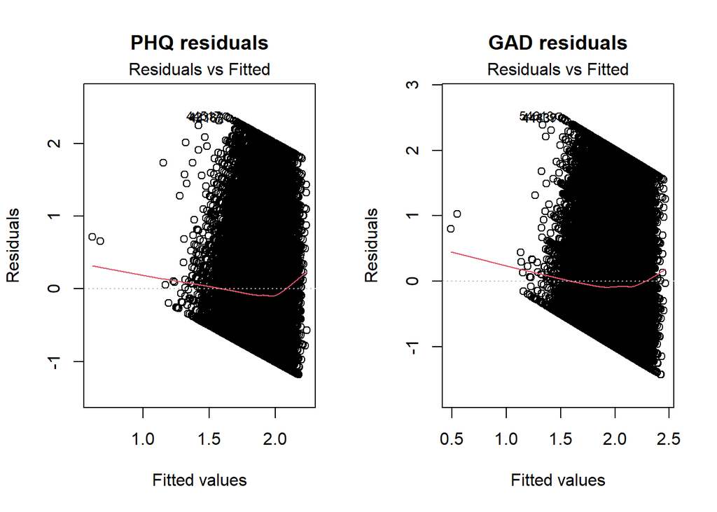

```r
# Check residual patterns for the two adjusted models.
par(mfrow = c(1, 2))
plot(adjusted_phq, which = 1, main = "PHQ residuals")
plot(adjusted_gad, which = 1, main = "GAD residuals")
```

```r
par(mfrow = c(1, 1))
```